Lake Name: Putnam Lake

Lake acreage: 222.1

County: PUTNAM

PWLID: 1302-0053

Waterbody Classification: B

Coordinates: 41.457911,-73.541719

Is this waterbody a public water supply: No

Are there DOH desingated beaches on this waterbody: Yes

Open Water Indicators

2018 Sampling Results

Seasonal Change

06-10

06-24

07-08

07-22

08-12

08-27

09-23

Clarity (m)

4.70

1.55

2.30

1.55

1.70

0.45

0.90

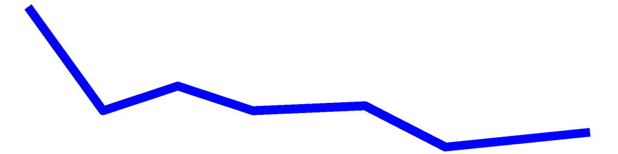

Surface TP (mg/L)

0.02

0.04

0.04

0.05

0.07

0.09

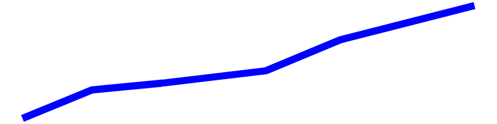

Surface TDP (mg/L)

0.01

0.02

0.01

0.03

0.04

0.05

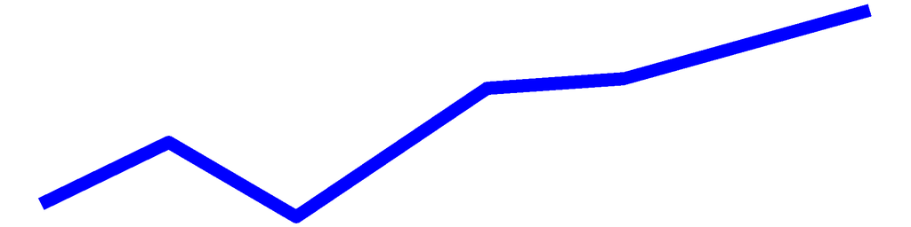

Deep TP (mg/L)

Deep TDP (mg/L)

TN (mg/L)

0.56

0.83

0.63

0.55

0.92

1.12

1.08

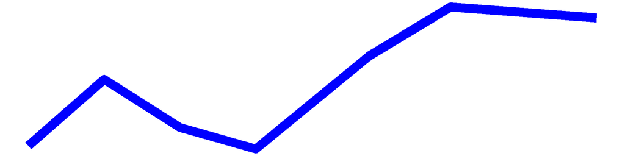

TDN (mg/L)

0.57

0.72

0.53

0.52

0.82

0.93

0.91

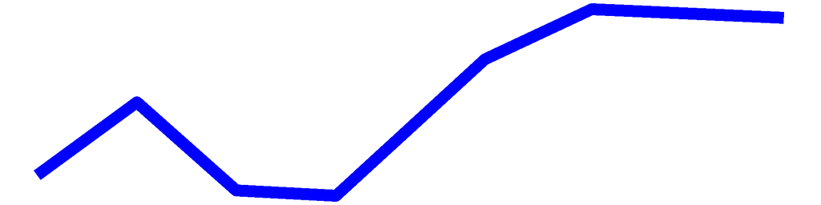

TN:TP

35.43

16.24

12.78

18.67

16.86

12.65

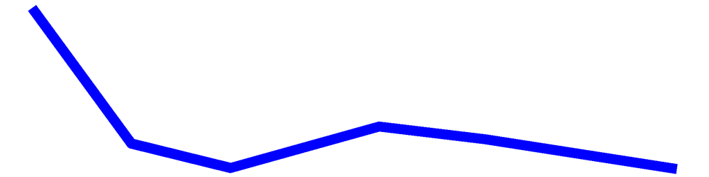

Surface NH3 (mg/L)

0.08

0.03

0.07

0.12

0.04

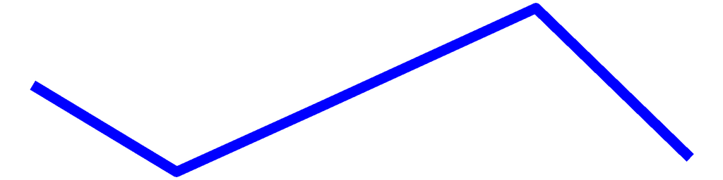

Deep NH3 (mg/L)

Chl.a (ug/L)

2.60

2.80

21.00

20.40

77.50

59.30

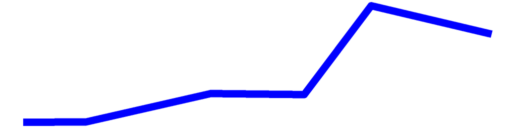

pH

7.46

7.76

7.62

7.59

7.96

7.52

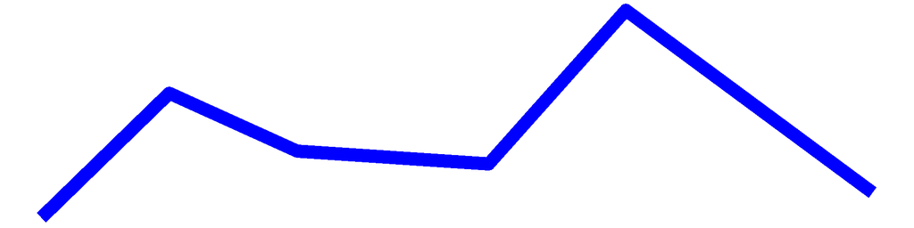

Cond (umho/cm)

745.30

599.90

709.10

643.50

592.00

608.90

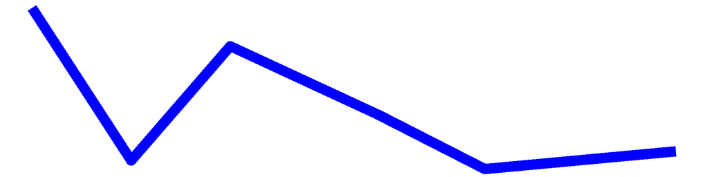

Surface Calcium (mg/L)

Bottom Calcium (mg/L)

Surface Chloride (mg/L)

111.10

127.50

Bottom Chloride (mg/L)

Upper Temp (degC)

23.00

28.00

26.00

28.00

27.00

21.00

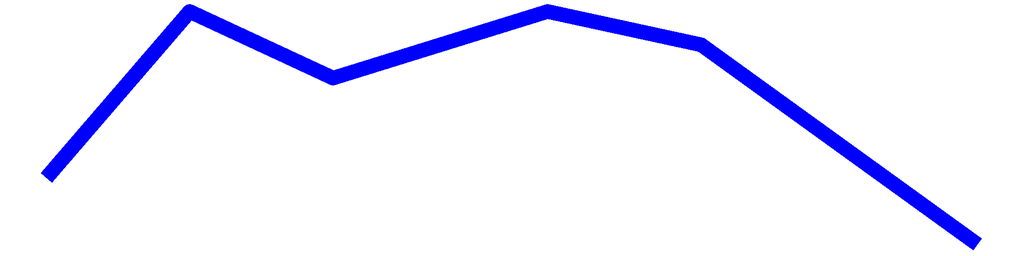

Deep Temp (degC)

FP BG Chl.a (ug/L)

2.45

17.00

17.47

25.47

107.79

82.16

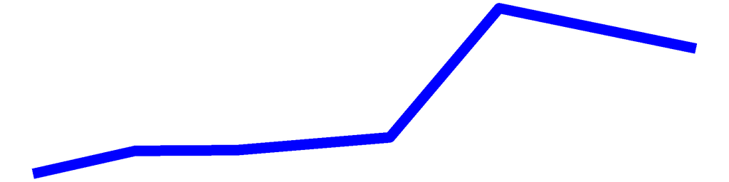

## Putnam Lake – Sampling Season Results

### HABs Status

#### Open Water Algae

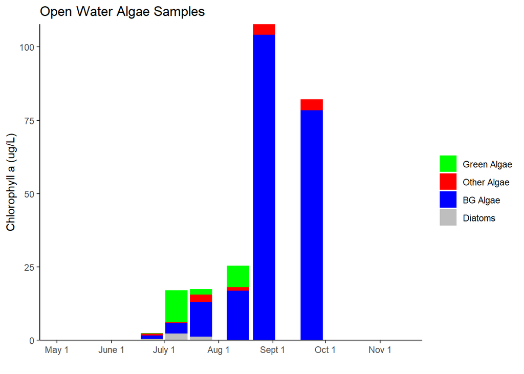

#### Shoreline Algae

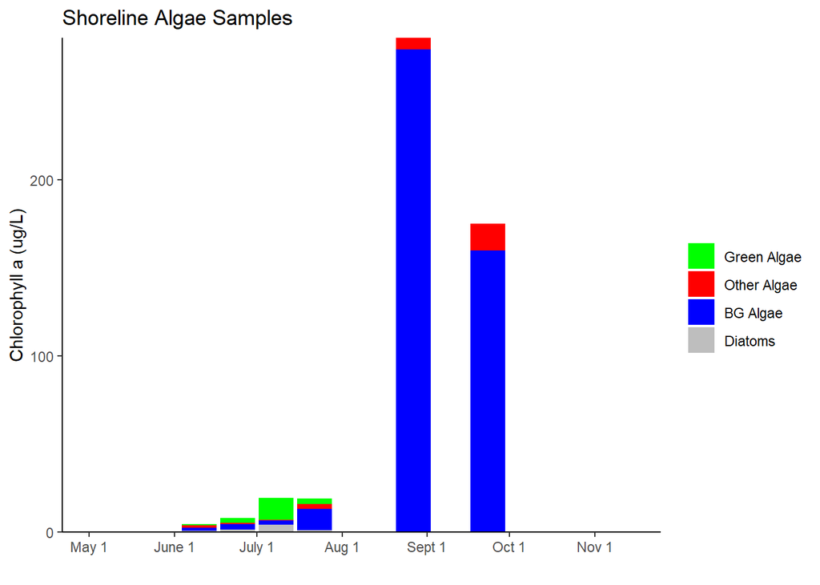

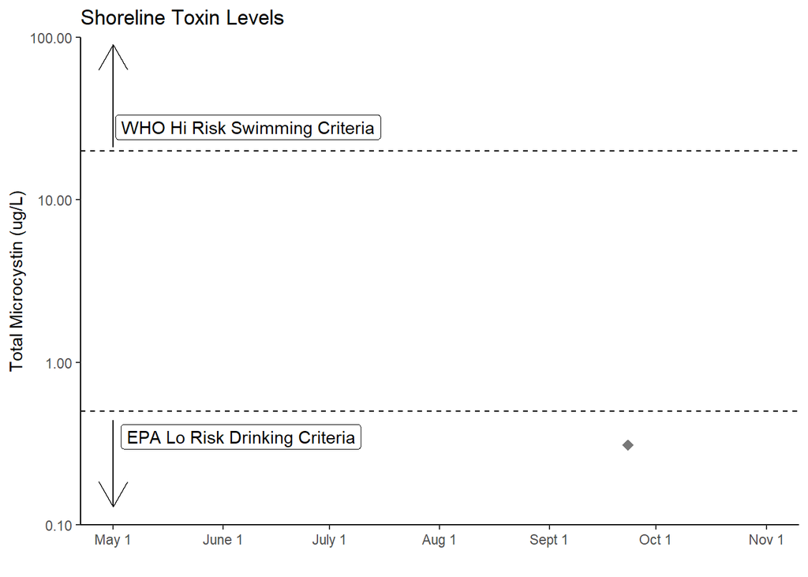

## Putnam Lake Long-Term Trend Analysis

#### Clarity

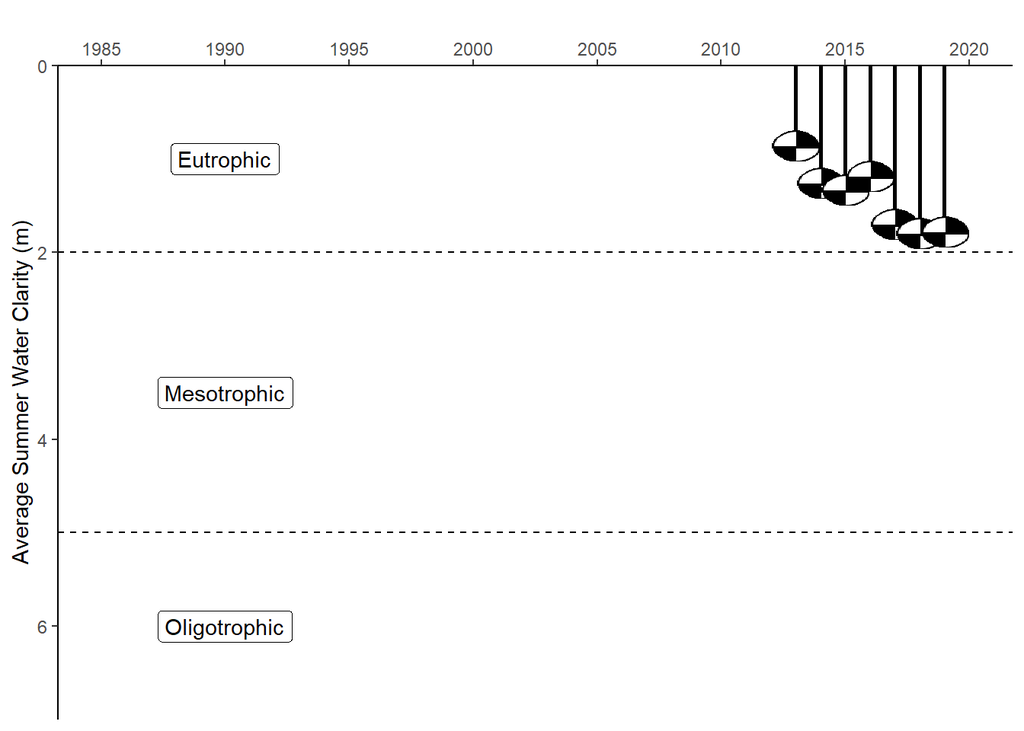

#### Chlorophyll *a*

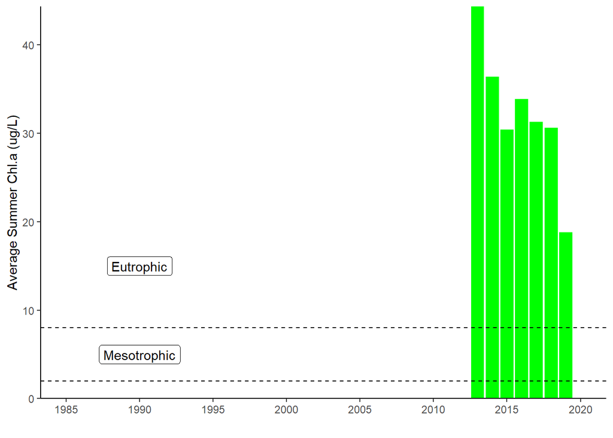

#### Surface and Deep Phosphorus

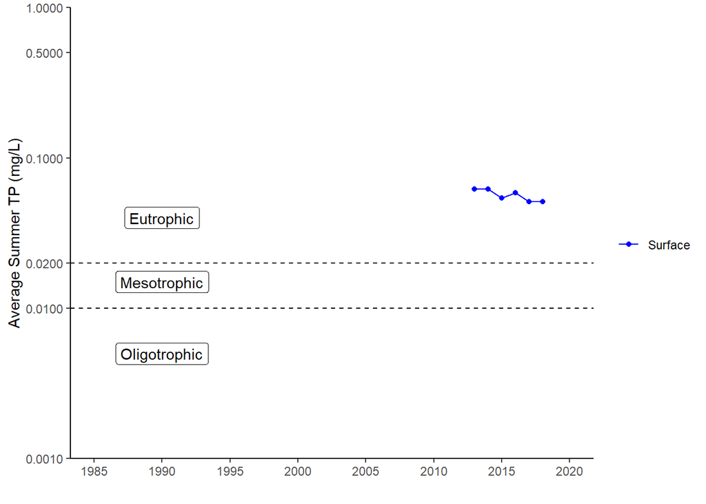

#### Nitrogen

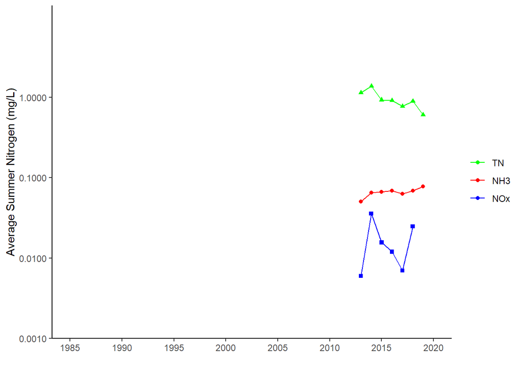

#### TN : TP

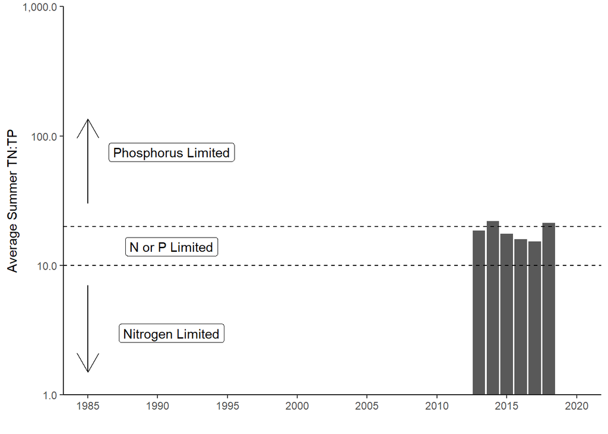

#### pH

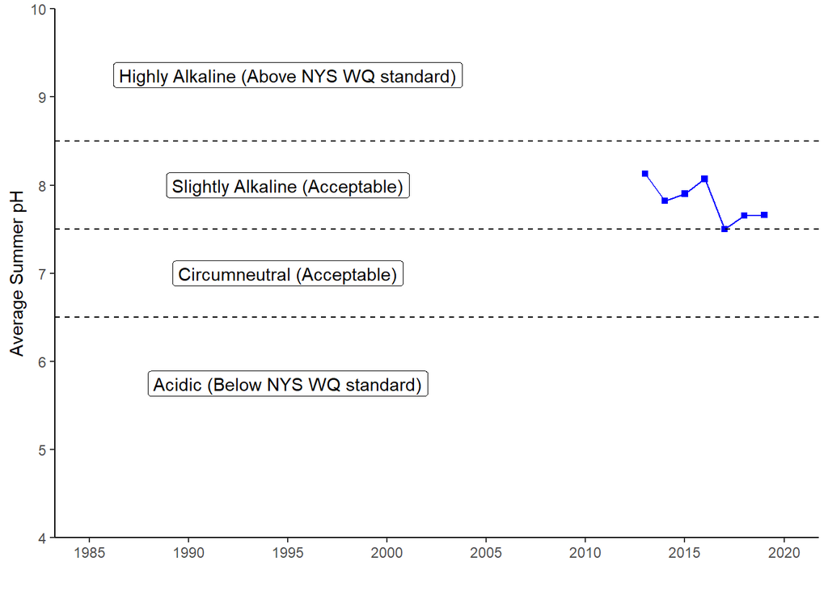

#### Specific Conductance

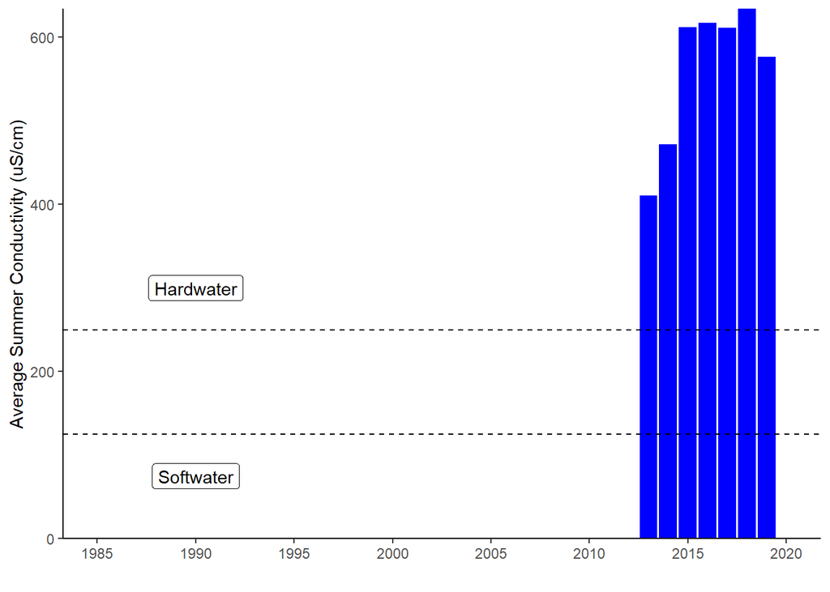

#### Calcium

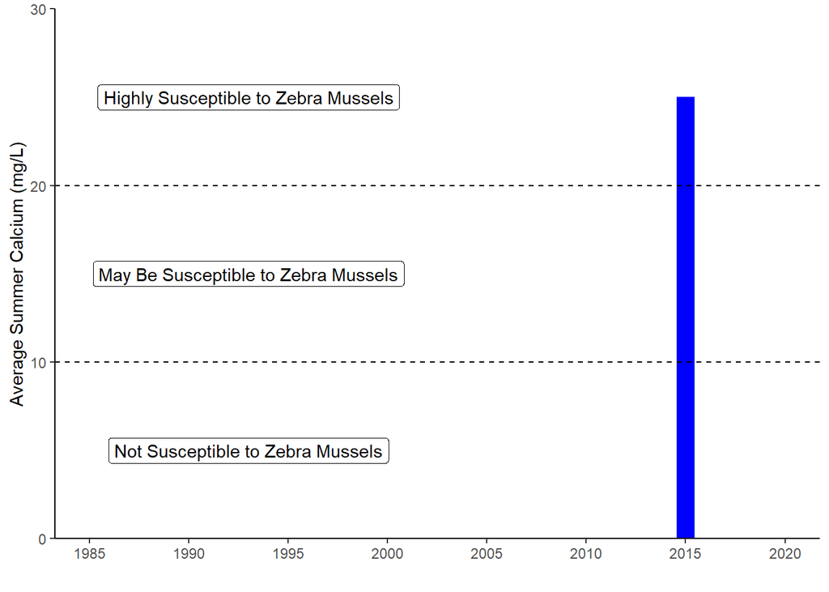

#### Chloride

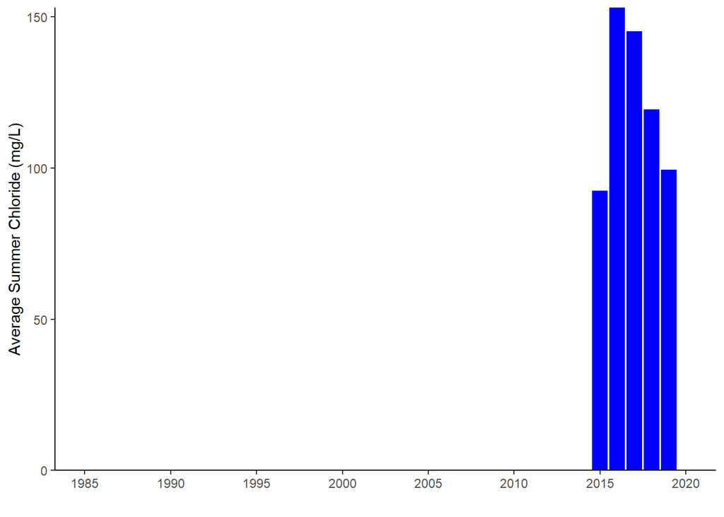

#### Color

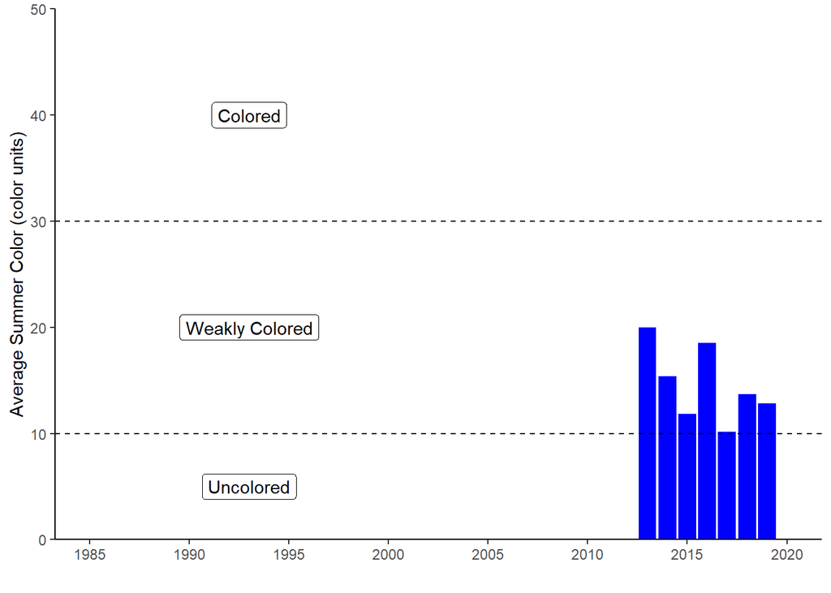

#### Surface and Deep Temperature

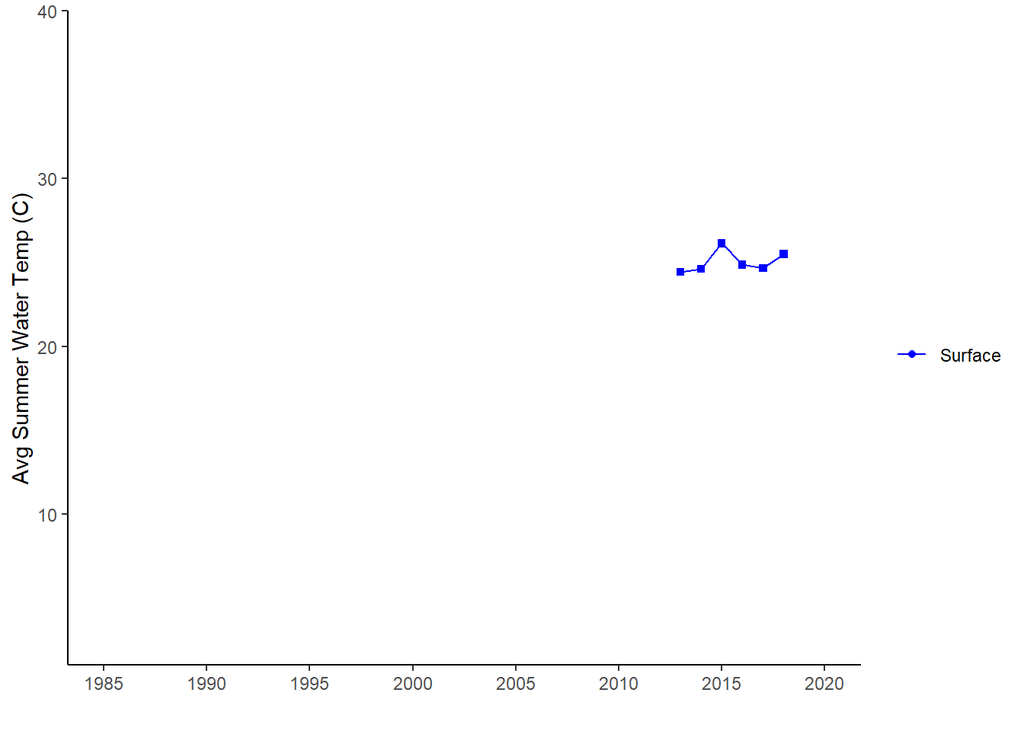

#### Lake Perception

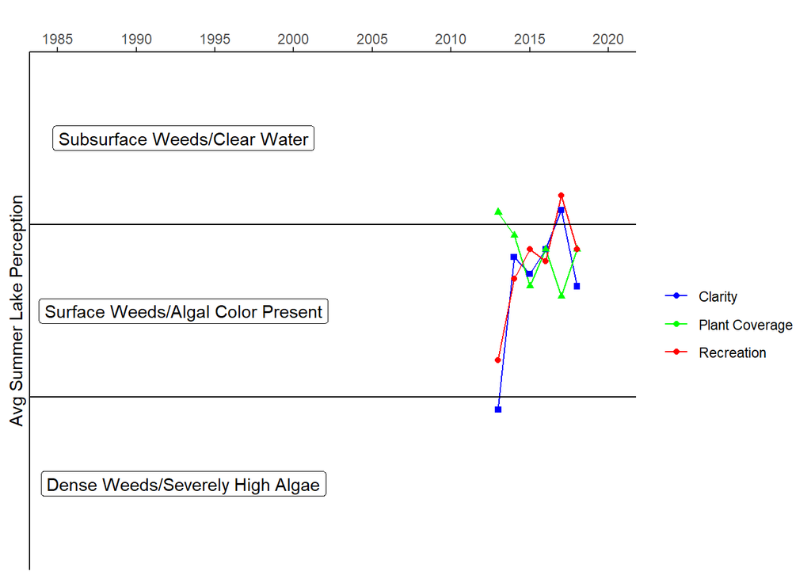

## Putnam Lake - In-Season Analysis

#### In Season Water Clarity

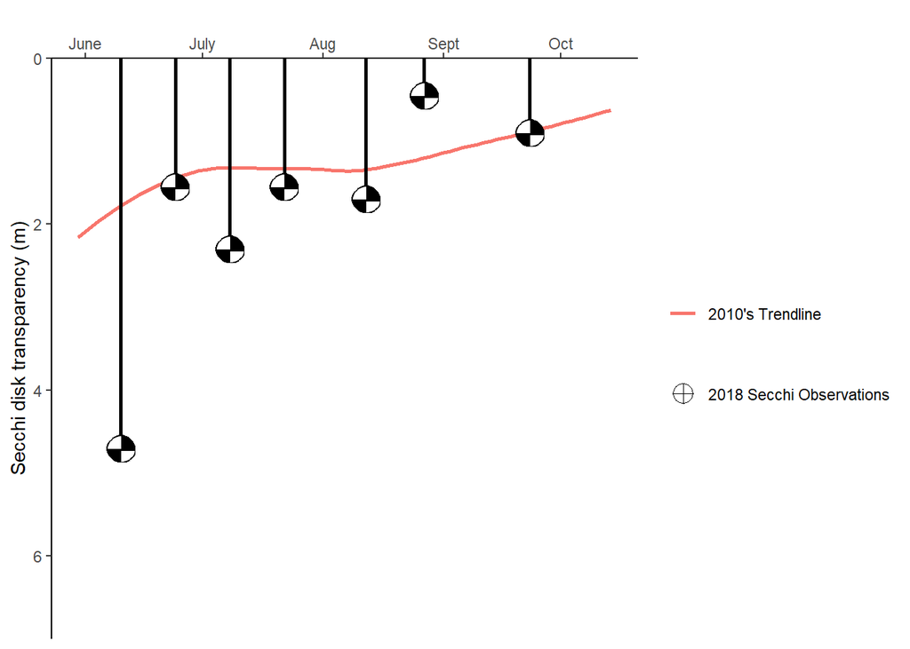

#### In Season Water Temperature

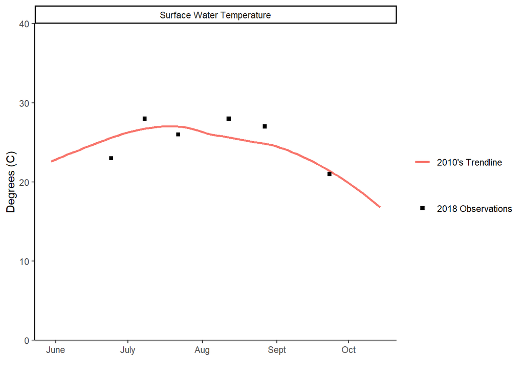